# Laboratorio de Filogeografía: Género *Hamadryas*

### 2.1.2 Riqueza y riqueza rarefaccionada de alelos

La riqueza corresponde al número de alelos y muchas veces nos interesa compararla entre distintas regiones o poblaciones. Sin embargo, cuando los tamaños de muestra no son iguales, esta comparación no es justa, ya que esperaríamos encontrar más alelos simplemente porque se muestrearon más individuos.

Por lo tanto, podemos calcular la riqueza rarefaccionada, que consiste en estimar cuántos alelos esperaríamos encontrar si todas las poblaciones tuvieran el mismo tamaño de muestra, generalmente igual al tamaño de la muestra más pequeña

```r
summary <- summary(micros_genind)

# Riqueza absoluta (sin rarefaccionar)
summary$pop.n.all
```

```
 Bo  CC  Cm  Co  Cp  Ct  EF  LC  Mn  Mo  NR  Ny RCh  SA  SG  SM  SN  Ve  Vi  Za
 14  17  14  18  13   9  16  13  13  15  17  16   7  11   8  11  11  16   8  18
```

```r
# Riqueza rarefaccionada
summary_rarefied <- PopGenReport::allel.rich(micros_genind, min.alleles = NULL)

knitr::kable(data.frame(
  N = summary$n.by.pop,
  Na = summary$pop.n.all,
  Ar = round(summary_rarefied$sum.richness, digits = 2)
))
```

Tabla comparativa de la riqueza y la riqueza rarefaccionada. N = número de individuos, Na = riqueza de alelos por población, Ar = riqueza rarefaccionada (min = 8)

|  | N | Na | Ar |
| --- | --- | --- | --- |
| Bo | 10 | 14 | 11.31 |
| CC | 10 | 17 | 13.45 |
| Cm | 10 | 14 | 10.28 |
| Co | 10 | 18 | 13.03 |
| Cp | 10 | 13 | 10.37 |
| Ct | 10 | 9 | 8.59 |
| EF | 10 | 16 | 12.95 |
| LC | 9 | 13 | 9.30 |
| Mn | 10 | 13 | 10.43 |
| Mo | 10 | 15 | 11.35 |
| NR | 10 | 17 | 13.01 |
| Ny | 10 | 16 | 11.76 |
| RCh | 8 | 7 | 6.44 |
| SA | 4 | 11 | 10.26 |
| SG | 10 | 8 | 7.36 |
| SM | 10 | 11 | 8.70 |
| SN | 10 | 11 | 8.69 |
| Ve | 9 | 16 | 13.11 |
| Vi | 10 | 8 | 7.47 |
| Za | 10 | 18 | 15.20 |

### 2.1.3 Heterocigocidad observada y esperada

- La heterocigosidad observada corresponde a la proporción promedio de individuos heterocigotos (entre loci) en la población.
- La heterocigosidad esperada corresponde a la proporción de heterocigotos que se esperaría a partir de las frecuencias alélicas si la población se encontrara en equilibrio de Hardy–Weinberg. También puede interpretarse como la probabilidad de que dos alelos tomados al azar sean distintos, por lo que constituye una medida de diversidad genética.
- Cuando la heterocigosidad observada es menor que la esperada, esto puede indicar la presencia de endogamia en la población.

```r
heterocigocity <- data.frame(
  Ho = round(hierfstat::Ho(micros_genind), 3),
  He = round(adegenet::Hs(micros_genind), 3)
) |>
  mutate(
    diferencia = ifelse(
      Ho > He,
      "Exceso",
      ifelse(Ho < He, "Déficit", "Iguales")
    )
  )

heterocigocity |> kable()
```

|  | Ho | He | diferencia |
| --- | --- | --- | --- |
| Bo | 0.250 | 0.283 | Déficit |
| CC | 0.233 | 0.426 | Déficit |
| Cm | 0.250 | 0.219 | Exceso |
| Co | 0.367 | 0.346 | Exceso |
| Cp | 0.067 | 0.233 | Déficit |
| Ct | 0.267 | 0.193 | Exceso |
| EF | 0.300 | 0.412 | Déficit |
| LC | 0.185 | 0.160 | Exceso |
| Mn | 0.317 | 0.248 | Exceso |
| Mo | 0.183 | 0.267 | Déficit |
| NR | 0.233 | 0.399 | Déficit |
| Ny | 0.100 | 0.283 | Déficit |
| RCh | 0.021 | 0.020 | Exceso |
| SA | 0.208 | 0.240 | Déficit |
| SG | 0.183 | 0.099 | Exceso |
| SM | 0.250 | 0.158 | Exceso |
| SN | 0.117 | 0.153 | Déficit |
| Ve | 0.148 | 0.417 | Déficit |
| Vi | 0.033 | 0.083 | Déficit |
| Za | 0.250 | 0.532 | Déficit |

Podemos estimar la presencia de endogamia mediante el coeficiente de endogamia

```r
basic_stats_micros <- hierfstat::basic.stats(micros_genind, diploid = TRUE)

Fis_micros <- apply(
  basic_stats_micros$Fis,
  MARGIN = 2,
  FUN = mean,
  na.rm = TRUE
) %>%
  round(digits = 3)

Fis_micros
```

```
    Bo     CC     Cm     Co     Cp     Ct     EF     LC     Mn     Mo     NR
 0.128  0.392 -0.004 -0.017  0.615 -0.067  0.294 -0.059 -0.161  0.260  0.486
    Ny    RCh     SA     SG     SM     SN     Ve     Vi     Za
 0.587  0.000  0.226 -0.500 -0.370  0.170  0.744  0.471  0.529
```

Hagamos una tabla resumen con todos los parámetros que hemos calculado

```r
micros_diversity <- data.frame(
  N = summary$n.by.pop,
  Na = summary$pop.n.all,
  Ar = round(summary_rarefied$sum.richness, digits = 2),
  Ho = heterocigocity$Ho,
  He = heterocigocity$He,
  Fis = Fis_micros
) |>
  rownames_to_column(var = "Pop")

micros_diversity |> kable()
```

| Pop | N | Na | Ar | Ho | He | Fis |
| --- | --- | --- | --- | --- | --- | --- |
| Bo | 10 | 14 | 11.31 | 0.250 | 0.283 | 0.128 |
| CC | 10 | 17 | 13.45 | 0.233 | 0.426 | 0.392 |
| Cm | 10 | 14 | 10.28 | 0.250 | 0.219 | -0.004 |
| Co | 10 | 18 | 13.03 | 0.367 | 0.346 | -0.017 |
| Cp | 10 | 13 | 10.37 | 0.067 | 0.233 | 0.615 |
| Ct | 10 | 9 | 8.59 | 0.267 | 0.193 | -0.067 |
| EF | 10 | 16 | 12.95 | 0.300 | 0.412 | 0.294 |
| LC | 9 | 13 | 9.30 | 0.185 | 0.160 | -0.059 |
| Mn | 10 | 13 | 10.43 | 0.317 | 0.248 | -0.161 |
| Mo | 10 | 15 | 11.35 | 0.183 | 0.267 | 0.260 |
| NR | 10 | 17 | 13.01 | 0.233 | 0.399 | 0.486 |
| Ny | 10 | 16 | 11.76 | 0.100 | 0.283 | 0.587 |
| RCh | 8 | 7 | 6.44 | 0.021 | 0.020 | 0.000 |
| SA | 4 | 11 | 10.26 | 0.208 | 0.240 | 0.226 |
| SG | 10 | 8 | 7.36 | 0.183 | 0.099 | -0.500 |
| SM | 10 | 11 | 8.70 | 0.250 | 0.158 | -0.370 |
| SN | 10 | 11 | 8.69 | 0.117 | 0.153 | 0.170 |
| Ve | 9 | 16 | 13.11 | 0.148 | 0.417 | 0.744 |
| Vi | 10 | 8 | 7.47 | 0.033 | 0.083 | 0.471 |
| Za | 10 | 18 | 15.20 | 0.250 | 0.532 | 0.529 |

## 2.2 Estructura genética

### 2.2.1 DAPC: Análisis de discriminantes de componentes principales

Muchas veces nos interesa conocer el número de grupos genéticos presentes en la muestra sin una hipótesis de cuáles son. Hay muchas aproximaciones para realizar esto (STRUCTURE, K-means, PCA, entre otras). Una de ellas es el análisis de discriminantes de componentes principales (DAPC).

Es un análisis multivariado en el que se parte la varianza presente en la muestra dentro y entre grupos de forma que se maximiza la discriminación entre los grupos. Primero los datos genéticos se transforman en componentes de un análisis de componentes principales. Posteriormente se identifican los grupos utilizando un análisis discriminante, en el cual se buscan grupos que representan la mayor parte de la variación entre ellos pero minimizan la variación entre los individuos que los componen.

Cuando no conocemos a qué grupo pertenece cada individuo, se puede utilizar un análisis de agrupamiento de K-means probando diferentes valores de K que representan distintos números de grupos genéticos.

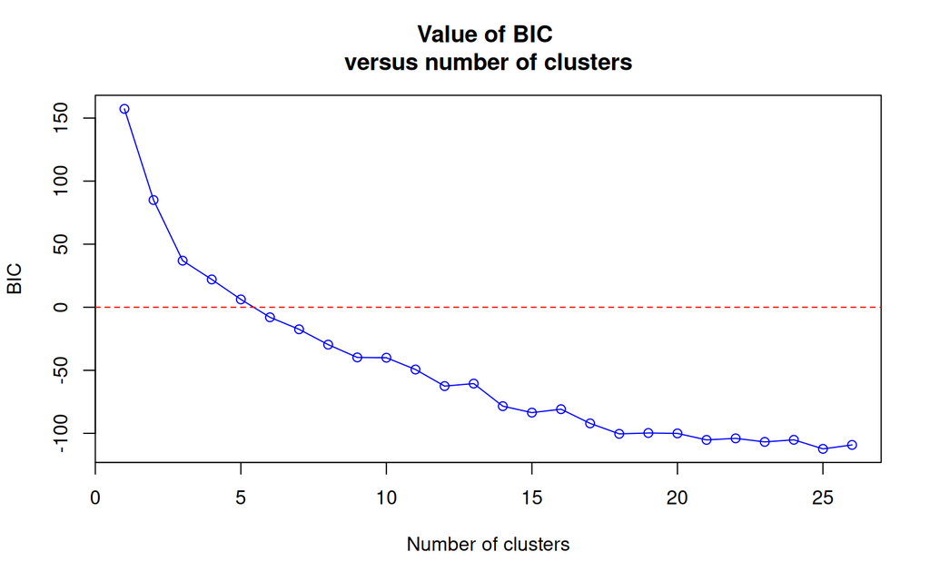

```
Choose the number of clusters (>=2):
```

```r
kclusters <- find.clusters(
  micros_genind,
  max.n.clust = 26,
  n.pca = 20,
  # n.clust = 4,
  # n.iter = 10
)
```

Después tenemos que escoger el número de componentes principales que queremos mantener en nuestro análisis

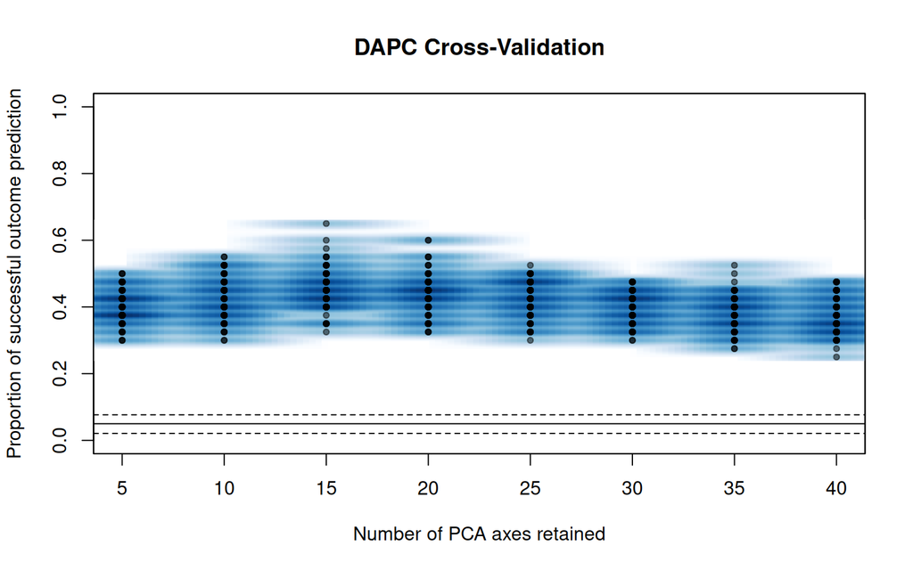

```r
mat <- tab(micros_genind, NA.method = "mean")
grp <- pop(micros_genind)
xval <- xvalDapc(
  mat,
  grp,
  n.pca.max = 100,
  training.set = 0.9,
  result = "groupMean",
  center = TRUE,
  scale = FALSE,
  n.pca = NULL,
  n.rep = 90,
  xval.plot = TRUE
)
```

```r
xval[2:6]
```

```
$`Median and Confidence Interval for Random Chance`
      2.5%        50%      97.5%
0.02088542 0.05000000 0.07673958

$`Mean Successful Assignment by Number of PCs of PCA`
        5        10        15        20        25        30        35        40
0.4022222 0.4244444 0.4511111 0.4380556 0.4227778 0.3986111 0.3825000 0.3733333

$`Number of PCs Achieving Highest Mean Success`
[1] "15"

$`Root Mean Squared Error by Number of PCs of PCA`
        5        10        15        20        25        30        35        40
0.5996990 0.5787199 0.5517271 0.5648562 0.5796671 0.6031687 0.6196269 0.6289431

$`Number of PCs Achieving Lowest MSE`
[1] "15"
```

Una vez que conocemos cuántos PCs retener durante el análisis, los corremos de nuevo para elegir el número adecuado.

```r
set.seed(12454)

kclusters <- find.clusters(
  micros_genind,
  max.n.clust = 26,
  n.pca = 15,
  n.clust = 3,
  n.iter = 10
)
```

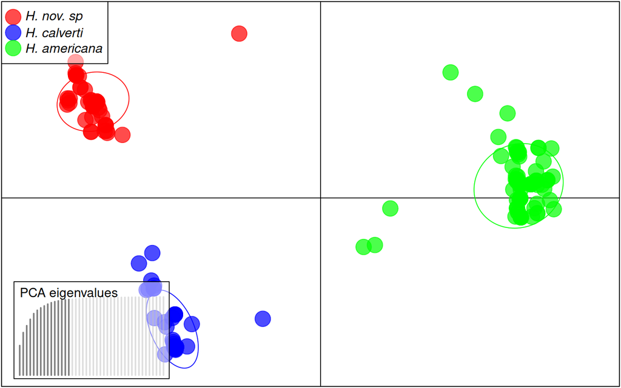

```r
dapc1 <- dapc(micros_genind, n.pca = 15, n.da = 2, kclusters$grp)

spp.label = c(
  expression(italic("H. nov. sp")),
  expression(italic("H. calverti")),
  expression(italic("H. americana"))
)

colors <- c("red", "blue", "green")

scatter(
  dapc1,
  scree.da = FALSE,
  bg = "white",
  col = colors,
  pch = 20,
  cstar = 0,
  cex = 4,
  clabel = 0,
  leg = TRUE,
  posi.leg = "topleft",
  txt.leg = spp.label,
  scree.pca = TRUE,
  posi.pca = "bottomleft"
)
```

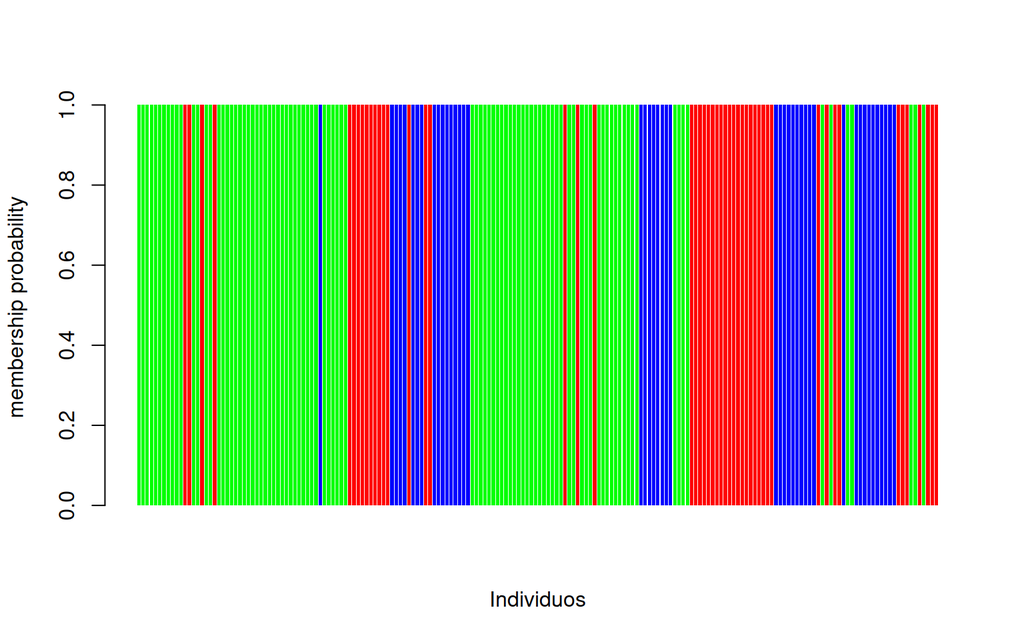

```r
compoplot.dapc(
  dapc1,
  posi = "bottomright",
  leg = FALSE,
  txt.leg = spp.label,
  lab = "a",
  xlab = "Individuos",
  col = colors
)
```

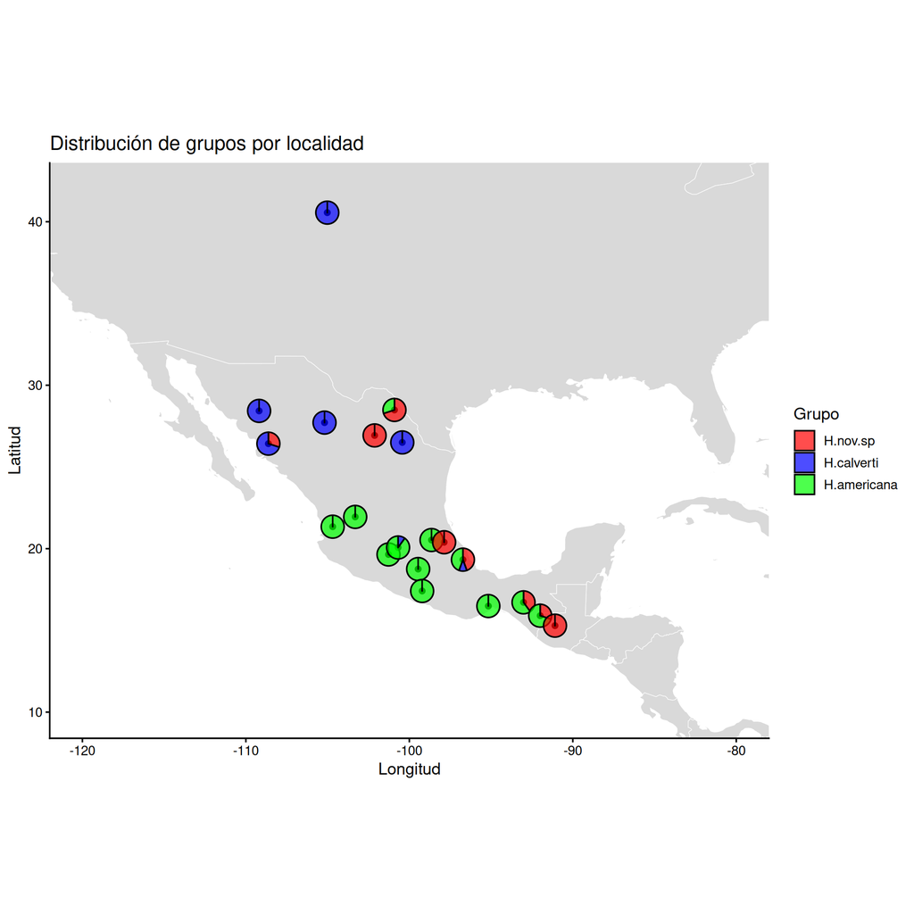

```r
info <- data.frame(
  ind = names(dapc1$grp),
  grp = as.factor(dapc1$grp),
  pop = as.factor(micros_genind$pop)
)

# ¿cuantos individuos de cada poblacion pertenecen a cada grupo?
tabla_pertenencia <- table(info$grp, info$pop) |> t()

colnames(tabla_pertenencia) <- make.names(c(
  "H.nov.sp",
  "H.calverti",
  "H.americana"
))

# Leer archivo de coordenadas
coords <- read.csv("hetaerina_practica_micros/01_metadata/coordinates_micros.csv")

frecuencias_por_pop <- tabla_pertenencia |>
  as.data.frame() |>
  rename(pop = "Var1", sp = "Var2") |>
  group_by(pop) |>
  mutate(Freq = Freq / sum(Freq)) |>
  ungroup() |>
  pivot_wider(id_cols = pop, names_from = sp, values_from = Freq) |>
  left_join(coords, by = c("pop" = "Code"))

# Generar poligono del mundo
mapa_mundo <- ggplot2::map_data("world")

# Mapa
ggplot() +
  geom_polygon(
    data = mapa_mundo,
    aes(x = long, y = lat, group = group),
    fill = "grey85",
    color = "white",
    linewidth = 0.2
  ) +
  geom_point(data = frecuencias_por_pop, aes(x = Lon, y = Lat)) +
  scatterpie::geom_scatterpie(
    data = frecuencias_por_pop,
    aes(x = Lon, y = Lat, r = 0.7),
    alpha = 0.7,
    cols = colnames(frecuencias_por_pop)[startsWith(
      colnames(frecuencias_por_pop),
      "H"
    )],
    long_format = F
  ) +
  scale_fill_manual(values = colors) +
  coord_fixed(xlim = c(-120, -80), ylim = c(10, 42)) +
  labs(
    title = "Distribución de grupos por localidad",
    x = "Longitud",
    y = "Latitud",
    fill = "Grupo"
  ) +
  theme_classic(base_size = 13)
```

### 2.2.2 Diferenciación Fst

La diferenciación genética ($F_{ST}$) es un estadístico que mide qué tan distintas son las poblaciones entre sí en términos de sus frecuencias alélicas. Cuantifica cuánto se reduce la heterocigosidad debido a la estructura de la población.

$$F_{ST} = \frac{H_T - H_S}{H_T}$$

Los valores de Fst varían entre 0 - 1. Cuando es 0 se interpreta como que las poblaciones son similares mientras que cuando es 1 hay mucha estructura genética y las poblaciones son distintas.

```r
fst_micros <- genet.dist(micros_genind, method = "WC84") %>% round(digits = 3)
fst_micros
```

```
        Bo     CC     Cm     Co     Cp     Ct     EF     LC     Mn     Mo
CC   0.290
Cm  -0.007  0.320
Co   0.019  0.235  0.032
Cp   0.116  0.323  0.136  0.154
Ct   0.674  0.371  0.712  0.627  0.703
EF   0.368  0.212  0.400  0.330  0.351  0.462
LC   0.447  0.461  0.478  0.436  0.404  0.703  0.190
Mn  -0.003  0.341  0.057  0.070  0.100  0.707  0.377  0.452
Mo  -0.009  0.296  0.014  0.057  0.071  0.676  0.358  0.423 -0.018
NR   0.059  0.131  0.060  0.061  0.130  0.541  0.163  0.276  0.074  0.044
Ny   0.060  0.310  0.084  0.067 -0.021  0.686  0.353  0.430  0.076  0.066
RCh  0.572  0.571  0.621  0.556  0.500  0.818  0.310  0.056  0.579  0.545
SA   0.025  0.319  0.124  0.051 -0.014  0.734  0.344  0.497  0.022  0.040
SG   0.702  0.534  0.744  0.635  0.760  0.710  0.497  0.763  0.745  0.724
SM   0.680  0.382  0.716  0.636  0.707  0.453  0.472  0.705  0.717  0.683
SN   0.526  0.512  0.568  0.504  0.470  0.741  0.155  0.264  0.510  0.500
Ve   0.197  0.154  0.199  0.159  0.152  0.480  0.144  0.205  0.234  0.186
Vi   0.546  0.518  0.580  0.526  0.440  0.759  0.257  0.060  0.549  0.514
Za   0.272  0.132  0.297  0.242  0.293  0.202  0.124  0.258  0.299  0.261
        NR     Ny    RCh     SA     SG     SM     SN     Ve     Vi
CC
Cm
Co
Cp
Ct
EF
LC
Mn
Mo
NR
Ny   0.112
RCh  0.396  0.524
SA   0.103 -0.101  0.684
SG   0.555  0.711  0.892  0.790
SM   0.535  0.693  0.833  0.757  0.626
SN   0.330  0.477  0.367  0.528  0.774  0.761
Ve   0.065  0.148  0.319  0.164  0.455  0.404  0.332
Vi   0.369  0.483  0.059  0.599  0.837  0.771  0.318  0.249
Za   0.131  0.286  0.369  0.261  0.433  0.333  0.331  0.088  0.320
```

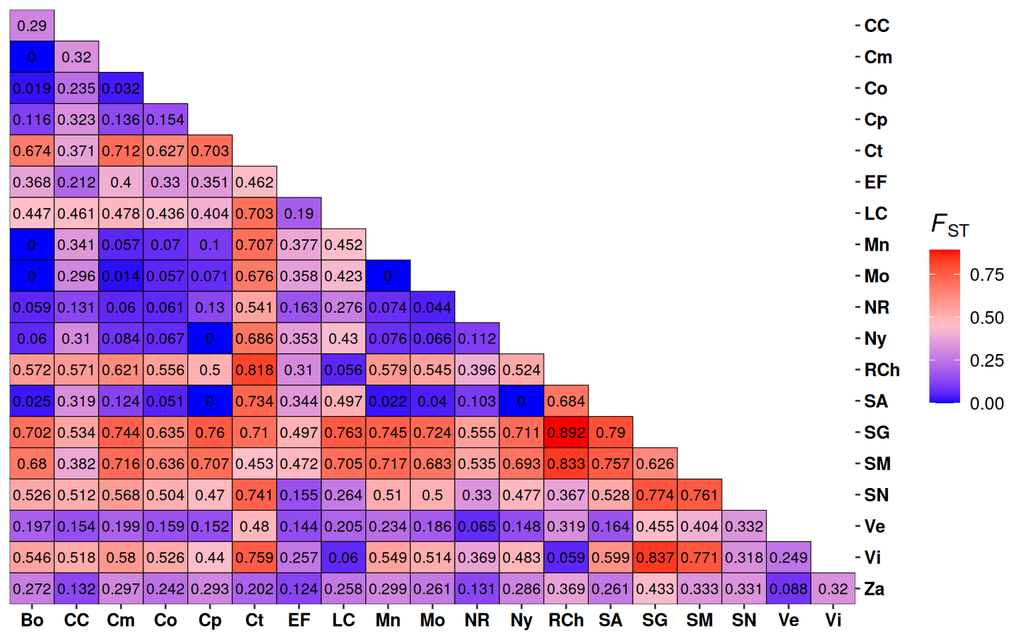

```r
#Ordenamos los datos de la matriz resultante
lab_order <- c(
  "Bo",
  "CC",
  "Cm",
  "Co",
  "Cp",
  "Ct",
  "EF",
  "LC",
  "Mn",
  "Mo",
  "NR",
  "Ny",
  "RCh",
  "SA",
  "SG",
  "SM",
  "SN",
  "Ve",
  "Vi",
  "Za"
)

df_fst <- tidy(as.dist(fst_micros))
names(df_fst) <- c("pop1", "pop2", "fst")

df_fst <- df_fst |>
  mutate(
    pop1 = factor(pop1, levels = lab_order),
    pop2 = factor(pop2, levels = lab_order),
    fst = ifelse(fst < 0, 0, fst)
  )


#Etiqueta en itálica
fst.label = expression(italic("F")[ST])

#Extraemos valores de Fst medios para hacer nuestro gradiente
mid = max(df_fst$fst) / 2

#Plotteamos el Heatmap
fst_micros_graf <- ggplot(
  data = df_fst,
  aes(x = pop1, y = fct_rev(pop2), fill = fst)
) +
  geom_tile(colour = "black") +
  geom_text(aes(label = fst), color = "black", size = 3) +
  scale_fill_gradient2(
    low = "blue",
    mid = "pink",
    high = "red",
    midpoint = mid,
    name = fst.label,
    limits = c(0, max(df_fst$fst)),
    breaks = c(0, 0.25, 0.5, 0.75, 1)
  ) +
  scale_x_discrete(expand = c(0, 0)) +
  scale_y_discrete(expand = c(0, 0), position = "right") +
  theme(
    axis.text = element_text(colour = "black", size = 10, face = "bold"),
    axis.title = element_blank(),
    panel.grid = element_blank(),
    panel.background = element_blank(),
    legend.position = "right",
    legend.title = element_text(size = 14, face = "bold"),
    legend.text = element_text(size = 10)
  )

fst_micros_graf
```

```r
kable(tabla_pertenencia)
```

|  | H.nov.sp | H.calverti | H.americana |
| --- | --- | --- | --- |
| Bo | 0 | 0 | 10 |
| CC | 4 | 0 | 6 |
| Cm | 0 | 0 | 10 |
| Co | 0 | 0 | 10 |
| Cp | 0 | 1 | 9 |
| Ct | 10 | 0 | 0 |
| EF | 3 | 7 | 0 |
| LC | 0 | 9 | 0 |
| Mn | 0 | 0 | 10 |
| Mo | 0 | 0 | 10 |
| NR | 3 | 0 | 7 |
| Ny | 0 | 0 | 10 |
| RCh | 0 | 8 | 0 |
| SA | 0 | 0 | 4 |
| SG | 10 | 0 | 0 |
| SM | 10 | 0 | 0 |
| SN | 0 | 10 | 0 |
| Ve | 4 | 1 | 4 |
| Vi | 0 | 10 | 0 |
| Za | 7 | 0 | 3 |

**TipSnapshot de los paquetes de R utilizados**

## 2.3 Renv snapshot

Generamos una fotografía de las versiones de todos los paquetes y dependecias que utilizamos en nuestro proyecto. Toda la información queda almacenada en el archivo `renv.lock`. Los paquetes se pueden instalar en una nueva computadora utilizando la función `renv::restore()`.

```r
renv::snapshot()
```

```
- The lockfile is already up to date.
```

Opcionalmente podemos organizar la información en una table

```r
lock <- renv::lockfile_read()

tabla <- data.frame(
  Package = names(lock$Packages),
  Version = sapply(lock$Packages, function(x) x$Version),
  row.names = NULL
)

knitr::kable(tabla)
```

| Package | Version |
| --- | --- |
| BiocGenerics | 0.54.1 |
| BiocManager | 1.30.27 |
| BiocVersion | 3.21.1 |
| Biostrings | 2.76.0 |
| DBI | 1.3.0 |
| GGally | 2.4.0 |
| GenomeInfoDb | 1.44.3 |
| GenomeInfoDbData | 1.2.14 |
| IRanges | 2.42.0 |
| MASS | 7.3-65 |
| Matrix | 1.7-4 |
| PopGenReport | 3.1.3 |
| R.methodsS3 | 1.8.2 |
| R.oo | 1.27.1 |
| R.utils | 2.13.0 |
| R6 | 2.6.1 |
| RColorBrewer | 1.1-3 |
| Rcpp | 1.1.1 |
| RcppArmadillo | 15.2.3-1 |
| RcppEigen | 0.3.4.0.2 |
| RcppParallel | 5.1.11-2 |
| Rdpack | 2.6.6 |
| RgoogleMaps | 1.5.3 |
| S4Vectors | 0.46.0 |
| S7 | 0.2.1 |
| UCSC.utils | 1.4.0 |
| XML | 3.99-0.22 |
| XVector | 0.48.0 |
| ade4 | 1.7-23 |
| adegenet | 2.1.11 |

[output cut: 164 more lines]